# Evidencia 1

Carlos Ivan Fonseca Mondragón

Antecedentes del Reto

En mayo del 2023, la OMS declaró de manera oficial el término de la emergencia global por parte del COVID-19, puesto a que ya no se considera como una situación crítica, en nuestro país, para julio del 2022, se reportó un estimado de 71.29% de mexiquenses completamente vacunados, dentro del Estado de México, en Marzo del 2022, se habían contabilizado un total de 491,221 casos, donde un 7.03% resultó en una defunción, dentro de mi localidad, los datos más recientes datan abril 2022, en donde a pesar de que solamente se presentaron 480 casos de manera oficial, un 24.37% de estas personas fallecieron.

La primera variante del virus que se propagó a nivel mundial fue la variante denominada SARS-CoV-2, la cual se detectó por primera vez en la ciudad de Wuhan, China, a finales del año 2019. Conforme este virus se fue expandiendo en todo el mundo, fueron surgiendo nuevas mutaciones rápidamente.

Actualmente, se han identificado diversas variantes preocupantes en distintas regiones del mundo, algunas de las más relevantes son: “Alfa” B.1.1.7, descubierta inicialmente en el Reino Unido a finales del 2020, la variante “Delta” B.1.617.2, la variante “Ómicron” B.1.1.529, que apareció por primera vez en Sudáfrica en Noviembre del 2021.

Refierendose a la búsqueda de información acerca de las variantes del virus en México, existen diversas fuentes confiables para hacerlo. Por ejemplo, es posible consultar el sitio web de la Secretaría de Salud de México, la cual ofrece datos actualizados hasta mediados del 2022 sobre la situación epidemiológica del país y las variantes del virus identificadas.

Si me encontrara en la situación del médico Li Wenliang, intentaría reportar la situación a una universidad u otro centro de investigación, donde sean capaces de garantizar la confidencialidad a fin de evitar problemas con el gobierno.

```r
library(seqinr)
library(adegenet)
library(ape)
library(ggtree)
library(DECIPHER)
library(viridis)
library(ggplot2)
library(phytools)
```

```r
variantes_Sars <- c('epsilon', 'omicron', 'zeta')

epsilon <- readDNAStringSet("/Users/krlos/Documents/TEC/2do/Entrega1/epsilon.fasta", format="fasta")
omicron <- readDNAStringSet("/Users/krlos/Documents/TEC/2do/Entrega1/omicron.fasta", format="fasta")
zeta <- readDNAStringSet("/Users/krlos/Documents/TEC/2do/Entrega1/zeta.fasta", format="fasta")
```

```r
calc_seq_size <- function(sequence) {
  i <- 1
  c <- 0
  while(!(is.na(sequence[i]))){
    c <- c + 1
    i <- i + 1
  }
  return(c)
}
```

```r
f2c <- function(f_strand) {
  c_strand <- c("3'-")
  for(i in 1:length(f_strand)){
    new_base <- switch(f_strand[i], "T"="A", "A"="T", "C"="G", "G"="C")
    c_strand <- append(c_strand, new_base)
  }
  c_strand <- append(c_strand, "-5'")
  return(c_strand)
}
```

```r
calc_base_percentage <- function(sequence) {
  cuenta_A <- 0
  cuenta_G <- 0
  cuenta_C <- 0
  cuenta_T <- 0
  for(i in 1:length(sequence)){
    switch(sequence[i],
           'A' = {cuenta_A <- cuenta_A+1},
           'G' = {cuenta_G <- cuenta_G+1},
           'C' = {cuenta_C <- cuenta_C+1},
           'T' = {cuenta_T <- cuenta_T+1})
  }
  cat(paste("Porcentaje de A = ", cuenta_A / length(sequence)*100))
  cat("\n")
  cat(paste("Porcentaje de G = ", cuenta_G / length(sequence)*100))
  cat("\n")
  cat(paste("Porcentaje de C= ", cuenta_C/length(sequence)*100))
  cat("\n")
  cat(paste("Porcentaje de T= ", cuenta_T/length(sequence)*100))
  cat("\n")
  cat(paste("Porcentaje GC = ", (cuenta_G+cuenta_C) / (length(sequence)) * 100), "%")
}
```

```r
for(segment in variantes_Sars){
  cat("                       ")
  cat("\n")
  cat(segment)
  file_path <- paste("/Users/krlos/Documents/TEC/2do/Entrega1/", segment, ".fasta", sep="")
  dna_seq <- unlist(strsplit(toString(read.fasta(file_path, seqonly = 1)), ""))
  complemento_adn <- (f2c(dna_seq))
  cat("\n")
  cat(paste(calc_seq_size(dna_seq), "Pares de bases"))
  cat("\n")
  cat(calc_base_percentage(append(dna_seq, complemento_adn)))
  cat("\n")
  cat(paste("5'-", paste(dna_seq, collapse=""), "-3'", sep=""))
  cat("\n")
  cat(paste(complemento_adn,collapse=""))
}
```

```
epsilon
```

```
29900 Pares de bases
Porcentaje de A =  31.0324069429116
Porcentaje de G =  18.9659208722116
Porcentaje de C=  18.9659208722116
Porcentaje de T=  31.0324069429116
Porcentaje GC =  37.9318417444233 %
5'-AAAGGTTTATACCTTCCCAGGTAACAAACCAACCAACTTTCGATCTCTTGTAGATCTGTT…-3'
3'-TTTCCAAATATGGAAGGGTCCATTGTTTGGTTGGTTGAAAGCTAGAGAACATCTAGACAA…-5'
omicron
```

```
29758 Pares de bases
Porcentaje de A =  30.9915757259841
Porcentaje de G =  18.9672277244371
Porcentaje de C=  18.9672277244371
Porcentaje de T=  30.9915757259841
Porcentaje GC =  37.9344554488742 %
5'-AGATCTGTTCTCTAAACGAACTTTAAAATCTGTGTGGCTGTCACTCGGCTGCATGCTTAG…-3'
3'-TCTAGACAAGAGATTTGCTTGAAATTTTAGACACACCGACAGTGAGCCGACGTACGAATC…-5'
zeta
```

```
29540 Pares de bases
Porcentaje de A =  31.0331403811652
Porcentaje de G =  18.9651670559561
Porcentaje de C=  18.9651670559561
Porcentaje de T=  31.0331403811652
Porcentaje GC =  37.9303341119123 %
5'-TCGTCCGTGTTGCAGCCGATCATCAGCACATCTAGGTTTTGTCCGGGTGTGACCGAAAGG…-3'
3'-AGCAGGCACAACGTCGGCTAGTAGTCGTGTAGATCCAAAACAGGCCCACACTGGCTTTCC…-5'
```

```r
combinados <- DNAStringSet(c(epsilon,omicron,zeta))
secuenciaFinal <- OrientNucleotides(combinados)
```

```
Time difference of 0.04 secs
```

```r
alineados <- AlignSeqs(secuenciaFinal)
```

[output not shown]

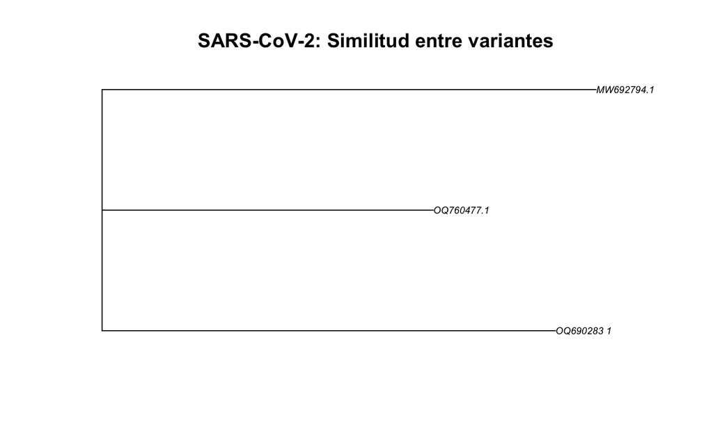

```r
BrowseSeqs(alineados, highlight=0)
writeXStringSet(alineados,file="variantes_aligned.fasta")
adn_alineado <- read.alignment("variantes_aligned.fasta", format ="fasta")
Dist<- dist.alignment(adn_alineado, matrix = "similarity")
arbol_filogenetico <- nj(Dist)
plot(arbol_filogenetico, cex = 0.6)
title("SARS-CoV-2: Similitud entre variantes")
```

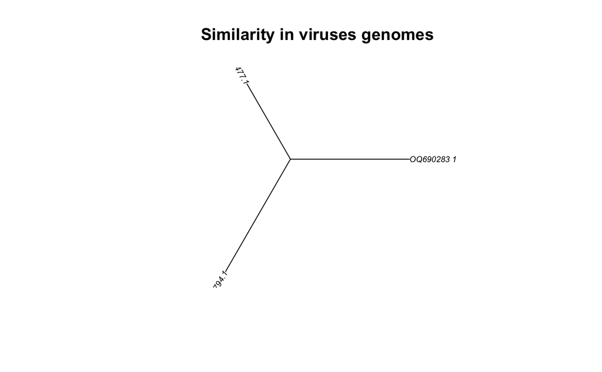

```r
tre <- nj(Dist)
tre <- ladderize(tre)
plot(tre, type="fan", cex = 0.6)
title("Similarity in viruses genomes")
```

Podemos observar que cada variante tiene un origen lo suficientemente distinto para no relacionarse entre si con las demás, quizas si se analizaran más cepas de este virus, seríamos capaces de llamar más parentezcos entre estas.